# An Introduction to Statistical Learning (2013)

Solutions to Applied Exercises

by Brian Hassett

# Chapter 2 Statistical Learning

This notebook is a rough outline of solutions to the applied exercises in Chapter 2 of **An Introduction to Statistical Learning** (James et al. (2013)[^1]).

## Setup

```r
library(ISLR)
library(tidyverse)
library(patchwork)
theme_set(theme_bw())

# Given a filename, return the filepath. Default folder is the `data` folder in the current working directory.
get_path <- function(filename) {
  str_c(getwd(), "data", filename, sep = "/")
}
```

## Exercise 8

### (a)

```r
college <- read.csv(get_path("College.csv"))
```

### (b)

```r
rownames(college) <- college[ , 1]
college <- college[ , -1]
college
```

|  | Private | Apps | Accept | Enroll | Top10perc | Top25perc | F.Undergrad | P.Undergrad | Outstate | Room.Board | Books | Personal | PhD | Terminal | S.F.Ratio | perc.alumni | Expend | Grad.Rate |
| --- | --- | --- | --- | --- | --- | --- | --- | --- | --- | --- | --- | --- | --- | --- | --- | --- | --- | --- |
| Abilene Christian University | Yes | 1660 | 1232 | 721 | 23 | 52 | 2885 | 537 | 7440 | 3300 | 450 | 2200 | 70 | 78 | 18.1 | 12 | 7041 | 60 |
| Adelphi University | Yes | 2186 | 1924 | 512 | 16 | 29 | 2683 | 1227 | 12280 | 6450 | 750 | 1500 | 29 | 30 | 12.2 | 16 | 10527 | 56 |
| Adrian College | Yes | 1428 | 1097 | 336 | 22 | 50 | 1036 | 99 | 11250 | 3750 | 400 | 1165 | 53 | 66 | 12.9 | 30 | 8735 | 54 |
| Agnes Scott College | Yes | 417 | 349 | 137 | 60 | 89 | 510 | 63 | 12960 | 5450 | 450 | 875 | 92 | 97 | 7.7 | 37 | 19016 | 59 |
| Alaska Pacific University | Yes | 193 | 146 | 55 | 16 | 44 | 249 | 869 | 7560 | 4120 | 800 | 1500 | 76 | 72 | 11.9 | 2 | 10922 | 15 |
| Albertson College | Yes | 587 | 479 | 158 | 38 | 62 | 678 | 41 | 13500 | 3335 | 500 | 675 | 67 | 73 | 9.4 | 11 | 9727 | 55 |
| Albertus Magnus College | Yes | 353 | 340 | 103 | 17 | 45 | 416 | 230 | 13290 | 5720 | 500 | 1500 | 90 | 93 | 11.5 | 26 | 8861 | 63 |
| Albion College | Yes | 1899 | 1720 | 489 | 37 | 68 | 1594 | 32 | 13868 | 4826 | 450 | 850 | 89 | 100 | 13.7 | 37 | 11487 | 73 |
| Albright College | Yes | 1038 | 839 | 227 | 30 | 63 | 973 | 306 | 15595 | 4400 | 300 | 500 | 79 | 84 | 11.3 | 23 | 11644 | 80 |
| Alderson-Broaddus College | Yes | 582 | 498 | 172 | 21 | 44 | 799 | 78 | 10468 | 3380 | 660 | 1800 | 40 | 41 | 11.5 | 15 | 8991 | 52 |

[output cut: 767 more lines]

### (c)

```r
summary(college)
```

```
   Private               Apps           Accept          Enroll       Top10perc       Top25perc      F.Undergrad     P.Undergrad
 Length:777         Min.   :   81   Min.   :   72   Min.   :  35   Min.   : 1.00   Min.   :  9.0   Min.   :  139   Min.   :    1.0
 Class :character   1st Qu.:  776   1st Qu.:  604   1st Qu.: 242   1st Qu.:15.00   1st Qu.: 41.0   1st Qu.:  992   1st Qu.:   95.0
 Mode  :character   Median : 1558   Median : 1110   Median : 434   Median :23.00   Median : 54.0   Median : 1707   Median :  353.0
                    Mean   : 3002   Mean   : 2019   Mean   : 780   Mean   :27.56   Mean   : 55.8   Mean   : 3700   Mean   :  855.3
                    3rd Qu.: 3624   3rd Qu.: 2424   3rd Qu.: 902   3rd Qu.:35.00   3rd Qu.: 69.0   3rd Qu.: 4005   3rd Qu.:  967.0
                    Max.   :48094   Max.   :26330   Max.   :6392   Max.   :96.00   Max.   :100.0   Max.   :31643   Max.   :21836.0
    Outstate       Room.Board       Books           Personal         PhD            Terminal       S.F.Ratio      perc.alumni
 Min.   : 2340   Min.   :1780   Min.   :  96.0   Min.   : 250   Min.   :  8.00   Min.   : 24.0   Min.   : 2.50   Min.   : 0.00
 1st Qu.: 7320   1st Qu.:3597   1st Qu.: 470.0   1st Qu.: 850   1st Qu.: 62.00   1st Qu.: 71.0   1st Qu.:11.50   1st Qu.:13.00
 Median : 9990   Median :4200   Median : 500.0   Median :1200   Median : 75.00   Median : 82.0   Median :13.60   Median :21.00
 Mean   :10441   Mean   :4358   Mean   : 549.4   Mean   :1341   Mean   : 72.66   Mean   : 79.7   Mean   :14.09   Mean   :22.74
 3rd Qu.:12925   3rd Qu.:5050   3rd Qu.: 600.0   3rd Qu.:1700   3rd Qu.: 85.00   3rd Qu.: 92.0   3rd Qu.:16.50   3rd Qu.:31.00
 Max.   :21700   Max.   :8124   Max.   :2340.0   Max.   :6800   Max.   :103.00   Max.   :100.0   Max.   :39.80   Max.   :64.00
     Expend        Grad.Rate
 Min.   : 3186   Min.   : 10.00
 1st Qu.: 6751   1st Qu.: 53.00
 Median : 8377   Median : 65.00
 Mean   : 9660   Mean   : 65.46
 3rd Qu.:10830   3rd Qu.: 78.00
 Max.   :56233   Max.   :118.00
```

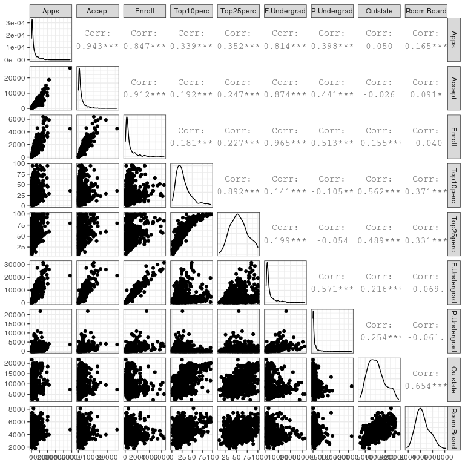

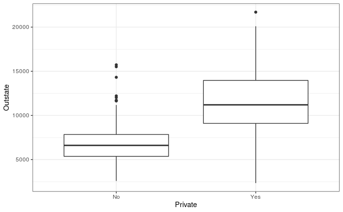

```r
Elite <- rep("No", nrow(college))
Elite[college$Top10perc > 50] = "Yes"
Elite <- as.factor(Elite)
college <- data.frame(college, Elite)
summary(college$Elite)
```

```
 No Yes
699  78
```

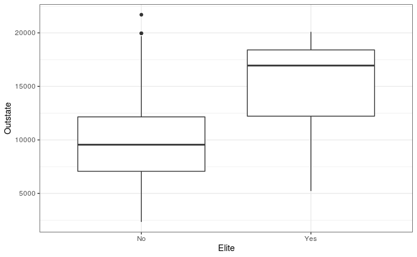

```r
ggplot(college) +
  geom_boxplot(aes(Elite, Outstate))
```

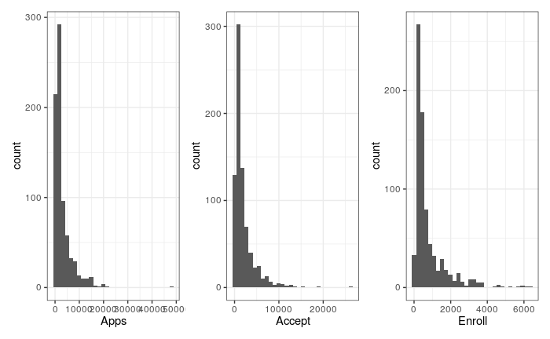

```r
p1 <- ggplot(college) +
  geom_histogram(aes(Apps))

p2 <- ggplot(college) +
  geom_histogram(aes(Accept))

p3 <- ggplot(college) +
  geom_histogram(aes(Enroll))

p1 + p2 + p3
```

Histograms for all numeric variables:

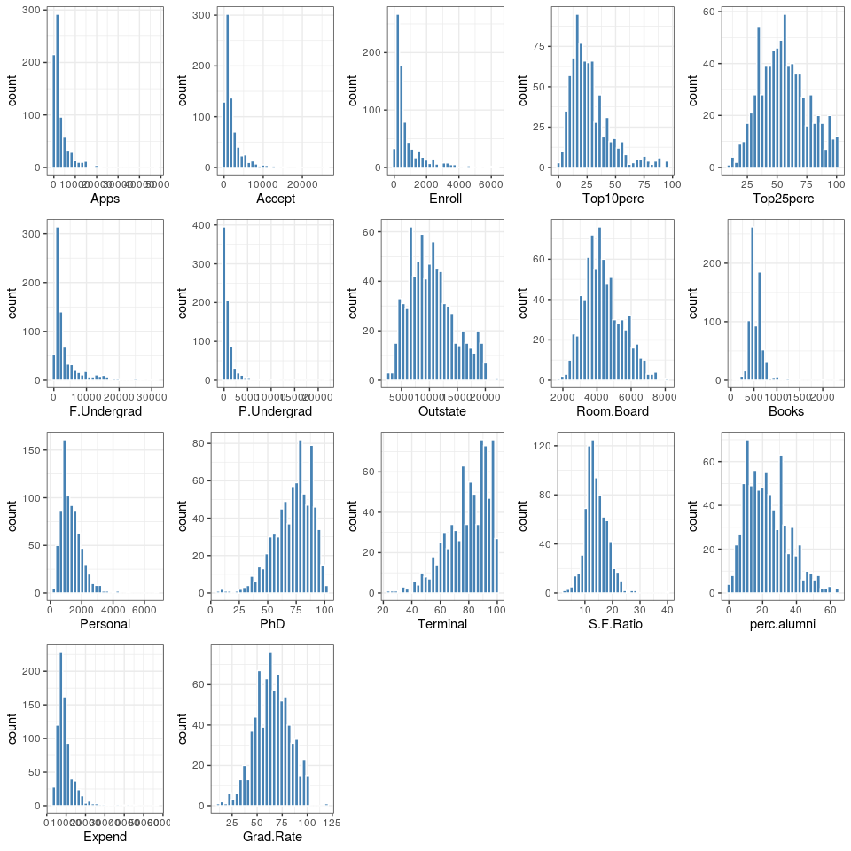

## Exercise 9

```r
Auto <- read.csv(get_path("Auto.csv"), na.strings = "?") %>% na.omit()
Auto
```

|  | mpg | cylinders | displacement | horsepower | weight | acceleration | year | origin | name |
| --- | --- | --- | --- | --- | --- | --- | --- | --- | --- |
| 1 | 18.0 | 8 | 307.0 | 130 | 3504 | 12.0 | 70 | 1 | chevrolet chevelle malibu |
| 2 | 15.0 | 8 | 350.0 | 165 | 3693 | 11.5 | 70 | 1 | buick skylark 320 |
| 3 | 18.0 | 8 | 318.0 | 150 | 3436 | 11.0 | 70 | 1 | plymouth satellite |
| 4 | 16.0 | 8 | 304.0 | 150 | 3433 | 12.0 | 70 | 1 | amc rebel sst |
| 5 | 17.0 | 8 | 302.0 | 140 | 3449 | 10.5 | 70 | 1 | ford torino |
| 6 | 15.0 | 8 | 429.0 | 198 | 4341 | 10.0 | 70 | 1 | ford galaxie 500 |
| 7 | 14.0 | 8 | 454.0 | 220 | 4354 | 9.0 | 70 | 1 | chevrolet impala |
| 8 | 14.0 | 8 | 440.0 | 215 | 4312 | 8.5 | 70 | 1 | plymouth fury iii |
| 9 | 14.0 | 8 | 455.0 | 225 | 4425 | 10.0 | 70 | 1 | pontiac catalina |
| 10 | 15.0 | 8 | 390.0 | 190 | 3850 | 8.5 | 70 | 1 | amc ambassador dpl |

[output cut: 382 more lines]

### (a)

Identify quantitative variables:

```r
is_numeric_col <- map_lgl(Auto, is.numeric)
names(Auto)[is_numeric_col]
```

```
[1] "mpg"          "cylinders"    "displacement" "horsepower"   "weight"       "acceleration" "year"         "origin"
```

Identify qualitative variables:

```r
names(Auto)[!is_numeric_col]
```

```
[1] "name"
```

The above code doesn’t take into account the fact that some of these variables might actually be qualitative variables coded with numbers. For example `origin` is actually a qualitative variable coded with an integer from {1, 2, 3}. `cylinders` could be considered either quantitative or qualitative. Unlike `origin`, there is a clear ordering of the `cylinders` variable, so it will be useful to treat it as a factor for plots. For now we will treat it as quantitative.

Update `origin` to be a factor:

```r
Auto <- Auto %>%
  mutate(origin = factor(origin))

is_numeric_col <- map_lgl(Auto, is.numeric)
names(Auto)[is_numeric_col]
```

```
[1] "mpg"          "cylinders"    "displacement" "horsepower"   "weight"       "acceleration" "year"
```

### (b)

Range of each numeric predictor:

```r
map_dbl(Auto[ , is_numeric_col], function(var) range(var)[2] - range(var)[1])
```

```
         mpg    cylinders displacement   horsepower       weight acceleration         year
        37.6          5.0        387.0        184.0       3527.0         16.8         12.0
```

### (c)

Mean of each numeric predictor:

```r
map_dbl(Auto[ , is_numeric_col], mean)
```

```
         mpg    cylinders displacement   horsepower       weight acceleration         year
   23.445918     5.471939   194.411990   104.469388  2977.584184    15.541327    75.979592
```

Standard deviation of each numeric predictor:

```r
map_dbl(Auto[ , is_numeric_col], sd)
```

```
         mpg    cylinders displacement   horsepower       weight acceleration         year
    7.805007     1.705783   104.644004    38.491160   849.402560     2.758864     3.683737
```

### (d)

```r
ranges <- map_dbl(Auto[-c(10:85), is_numeric_col], function(var) range(var)[2] - range(var)[1])
means <- map_dbl(Auto[-c(10:85), is_numeric_col], mean)
sds <- map_dbl(Auto[-c(10:85), is_numeric_col], sd)

writeLines("Ranges:")
```

```
Ranges:
```

```r
ranges
```

```
         mpg    cylinders displacement   horsepower       weight acceleration         year
        35.6          5.0        387.0        184.0       3348.0         16.3         12.0
```

```r
writeLines("Means:")
```

```
Means:
```

```r
means
```

```
         mpg    cylinders displacement   horsepower       weight acceleration         year
   24.404430     5.373418   187.240506   100.721519  2935.971519    15.726899    77.145570
```

```r
writeLines("Standard Deviations:")
```

```
Standard Deviations:
```

```r
sds
```

```
         mpg    cylinders displacement   horsepower       weight acceleration         year
    7.867283     1.654179    99.678367    35.708853   811.300208     2.693721     3.106217
```

### (e)

**Histograms**

Plot histograms of quantitative variables:

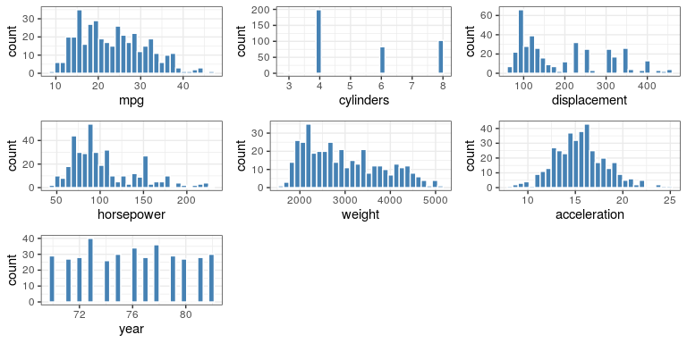

Pairs plots:

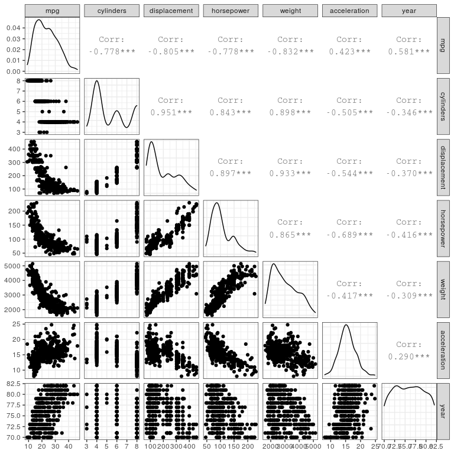

**Scatter plots**

`weight` and `mpg`

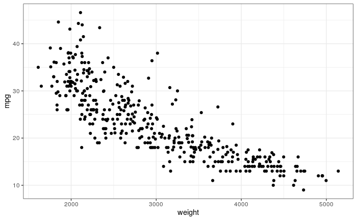

```r
ggplot(Auto) +
  geom_point(aes(weight, mpg))
```

`weight` and `mpg` facetted by `cylinders`

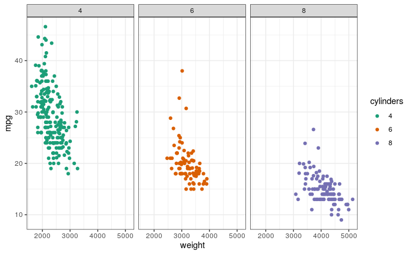

```r
Auto %>%
  mutate(cylinders = factor(cylinders)) %>%
  filter(cylinders != 3, cylinders != 5) %>%
  ggplot() +
    geom_point(aes(weight, mpg, color = cylinders)) +
    facet_wrap( ~ cylinders) +
    scale_color_brewer(palette = "Dark2")
```

`weight` and `mpg` facetted by `cylinders` with highlighting:

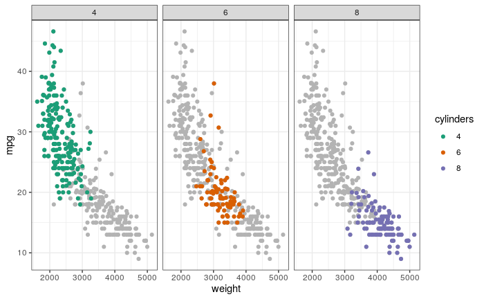

```r
Auto %>%
  mutate(cylinders = factor(cylinders)) %>%
  filter(cylinders != 3, cylinders != 5) %>%
  ggplot(aes(weight, mpg)) +
    geom_point(data = select(Auto, -cylinders), color = "grey70") +
    geom_point(aes(color = cylinders)) +
    facet_wrap( ~ cylinders) +
    scale_color_brewer(palette = "Dark2")
```

**Boxplots**

`cylinders` and `mpg`:

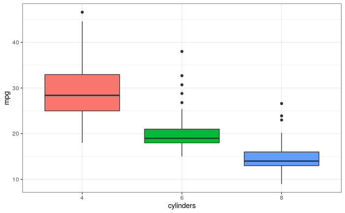

```r
Auto %>%
  mutate(cylinders = factor(cylinders)) %>%
  filter(cylinders != 3, cylinders != 5) %>%
  ggplot() +
    geom_boxplot(aes(cylinders, mpg, fill = cylinders),
                 show.legend = FALSE)
```

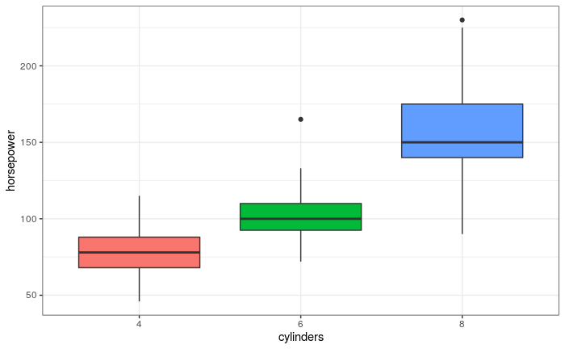

```r
Auto %>%
  mutate(cylinders = factor(cylinders)) %>%
  filter(cylinders != 3, cylinders != 5) %>%
  ggplot() +
    geom_boxplot(aes(cylinders, horsepower, fill = cylinders),
                 show.legend = FALSE)
```

### (f)

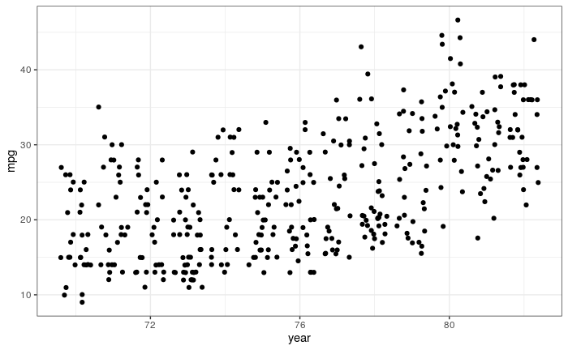

```r
ggplot(Auto) +
  geom_jitter(aes(year, mpg))
```

## Exercise 10

```r
library(MASS)
Boston
```

|  | crim | zn | indus | chas | nox | rm | age | dis | rad | tax | ptratio | black | lstat | medv |
| --- | --- | --- | --- | --- | --- | --- | --- | --- | --- | --- | --- | --- | --- | --- |
| 1 | 0.00632 | 18.0 | 2.31 | 0 | 0.5380 | 6.575 | 65.2 | 4.0900 | 1 | 296 | 15.3 | 396.90 | 4.98 | 24.0 |
| 2 | 0.02731 | 0.0 | 7.07 | 0 | 0.4690 | 6.421 | 78.9 | 4.9671 | 2 | 242 | 17.8 | 396.90 | 9.14 | 21.6 |
| 3 | 0.02729 | 0.0 | 7.07 | 0 | 0.4690 | 7.185 | 61.1 | 4.9671 | 2 | 242 | 17.8 | 392.83 | 4.03 | 34.7 |
| 4 | 0.03237 | 0.0 | 2.18 | 0 | 0.4580 | 6.998 | 45.8 | 6.0622 | 3 | 222 | 18.7 | 394.63 | 2.94 | 33.4 |
| 5 | 0.06905 | 0.0 | 2.18 | 0 | 0.4580 | 7.147 | 54.2 | 6.0622 | 3 | 222 | 18.7 | 396.90 | 5.33 | 36.2 |
| 6 | 0.02985 | 0.0 | 2.18 | 0 | 0.4580 | 6.430 | 58.7 | 6.0622 | 3 | 222 | 18.7 | 394.12 | 5.21 | 28.7 |
| 7 | 0.08829 | 12.5 | 7.87 | 0 | 0.5240 | 6.012 | 66.6 | 5.5605 | 5 | 311 | 15.2 | 395.60 | 12.43 | 22.9 |
| 8 | 0.14455 | 12.5 | 7.87 | 0 | 0.5240 | 6.172 | 96.1 | 5.9505 | 5 | 311 | 15.2 | 396.90 | 19.15 | 27.1 |
| 9 | 0.21124 | 12.5 | 7.87 | 0 | 0.5240 | 5.631 | 100.0 | 6.0821 | 5 | 311 | 15.2 | 386.63 | 29.93 | 16.5 |
| 10 | 0.17004 | 12.5 | 7.87 | 0 | 0.5240 | 6.004 | 85.9 | 6.5921 | 5 | 311 | 15.2 | 386.71 | 17.10 | 18.9 |

[output cut: 496 more lines]

### (a)

```r
dim(Boston)
```

```
[1] 506  14
```

```r
bh_print_data_summary(Boston)
```

```
                      [,1]
num_rows              "   506"
num_cols              "    14"
num_categorical_cols  "     0"
num_numeric_cols      "    14"
all_missing_cols      "     0"
complete_cols         "    14"
total_missing         "     0"
total_percent_missing "     0"
total_data_points     " 7,084"
size_bytes            "54,944"
```

```r
is_numeric_col <- map_lgl(Boston, is.numeric)
names(Boston)[is_numeric_col]
```

```
 [1] "crim"    "zn"      "indus"   "chas"    "nox"     "rm"      "age"     "dis"     "rad"     "tax"     "ptratio" "black"   "lstat"
[14] "medv"
```

```r
summary(Boston)
```

```
      crim                zn             indus            chas              nox               rm             age              dis
 Min.   : 0.00632   Min.   :  0.00   Min.   : 0.46   Min.   :0.00000   Min.   :0.3850   Min.   :3.561   Min.   :  2.90   Min.   : 1.130
 1st Qu.: 0.08205   1st Qu.:  0.00   1st Qu.: 5.19   1st Qu.:0.00000   1st Qu.:0.4490   1st Qu.:5.886   1st Qu.: 45.02   1st Qu.: 2.100
 Median : 0.25651   Median :  0.00   Median : 9.69   Median :0.00000   Median :0.5380   Median :6.208   Median : 77.50   Median : 3.207
 Mean   : 3.61352   Mean   : 11.36   Mean   :11.14   Mean   :0.06917   Mean   :0.5547   Mean   :6.285   Mean   : 68.57   Mean   : 3.795
 3rd Qu.: 3.67708   3rd Qu.: 12.50   3rd Qu.:18.10   3rd Qu.:0.00000   3rd Qu.:0.6240   3rd Qu.:6.623   3rd Qu.: 94.08   3rd Qu.: 5.188
 Max.   :88.97620   Max.   :100.00   Max.   :27.74   Max.   :1.00000   Max.   :0.8710   Max.   :8.780   Max.   :100.00   Max.   :12.127
      rad              tax           ptratio          black            lstat            medv
 Min.   : 1.000   Min.   :187.0   Min.   :12.60   Min.   :  0.32   Min.   : 1.73   Min.   : 5.00
 1st Qu.: 4.000   1st Qu.:279.0   1st Qu.:17.40   1st Qu.:375.38   1st Qu.: 6.95   1st Qu.:17.02
 Median : 5.000   Median :330.0   Median :19.05   Median :391.44   Median :11.36   Median :21.20
 Mean   : 9.549   Mean   :408.2   Mean   :18.46   Mean   :356.67   Mean   :12.65   Mean   :22.53
 3rd Qu.:24.000   3rd Qu.:666.0   3rd Qu.:20.20   3rd Qu.:396.23   3rd Qu.:16.95   3rd Qu.:25.00
 Max.   :24.000   Max.   :711.0   Max.   :22.00   Max.   :396.90   Max.   :37.97   Max.   :50.00
```

**Histograms**

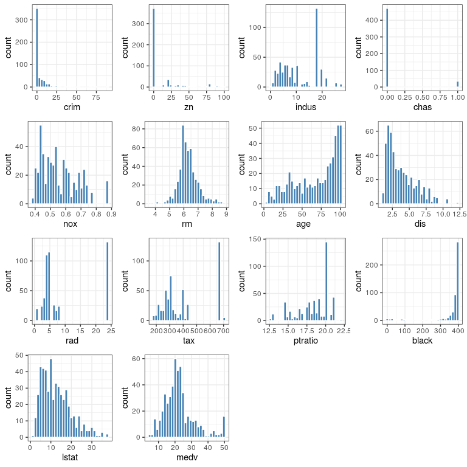

### (b)

**Scatter plots**

`crim` vs all other variables:

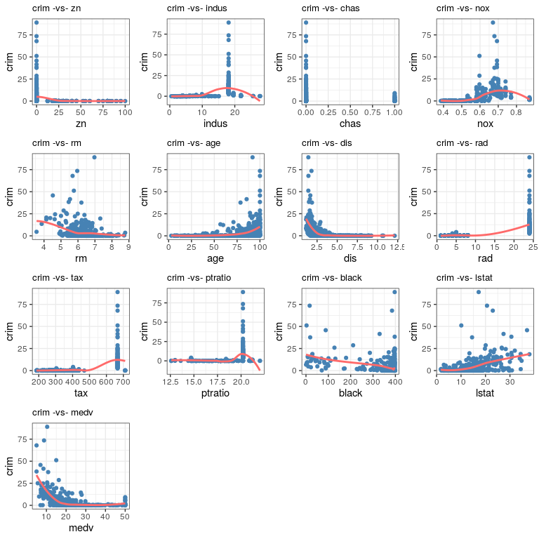

Check the correlation of variables with `crim`:

```r
cors
```

```
       crim          zn       indus        chas         nox          rm         age         dis         rad         tax     ptratio
 1.00000000 -0.20046922  0.40658341 -0.05589158  0.42097171 -0.21924670  0.35273425 -0.37967009  0.62550515  0.58276431  0.28994558
      black       lstat        medv
-0.38506394  0.45562148 -0.38830461
```

Do a pairs plot of the correlated ones:

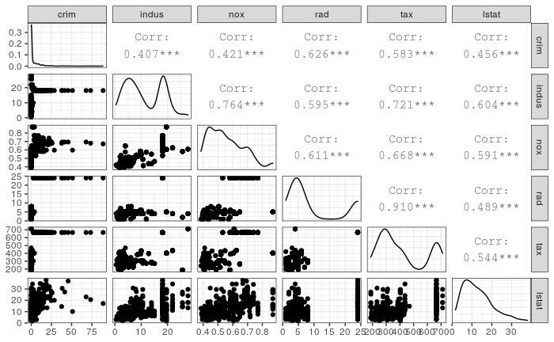

### (c)

Base on the scatter plots of `crim` vs the other variables, `age`, `dis` and `medv` seem to have an association with `crim`.

### (d)

```r
Boston %>%
  dplyr::select(c(crim, tax, ptratio)) %>%
  summary()
```

```
      crim               tax           ptratio
 Min.   : 0.00632   Min.   :187.0   Min.   :12.60
 1st Qu.: 0.08205   1st Qu.:279.0   1st Qu.:17.40
 Median : 0.25651   Median :330.0   Median :19.05
 Mean   : 3.61352   Mean   :408.2   Mean   :18.46
 3rd Qu.: 3.67708   3rd Qu.:666.0   3rd Qu.:20.20
 Max.   :88.97620   Max.   :711.0   Max.   :22.00
```

`crim` looks to have some extreme outliers at the high end. The boxplot appears distorted because there are so many outliers:

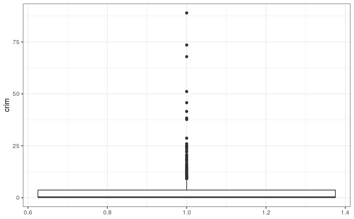

A histogram shows a similar story:

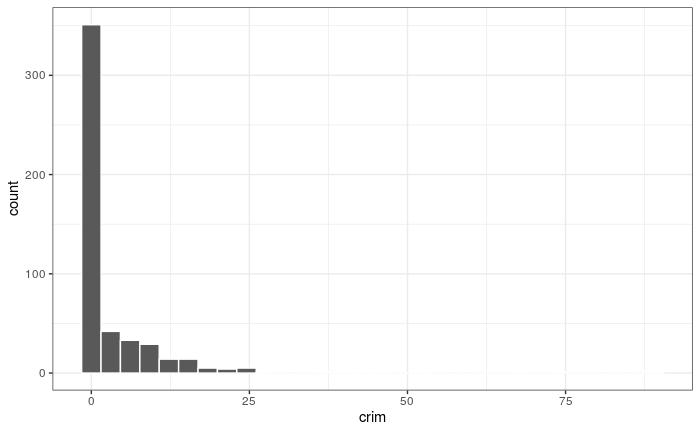

The `tax` variable has no outliers:

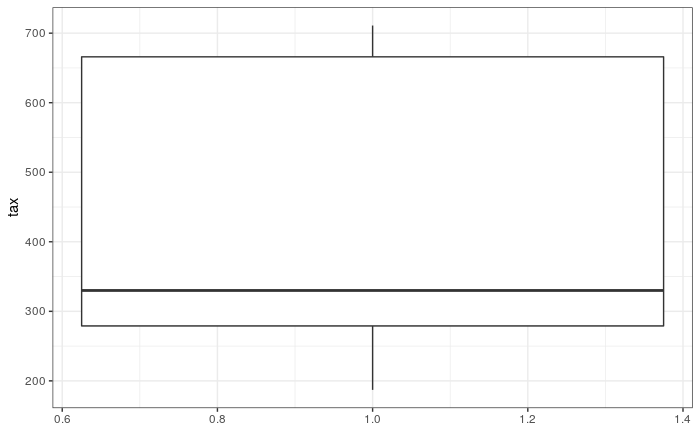

The histogram shows that there are some values which appear to be outliers at the high end, but the boxplot did not deem them to be:

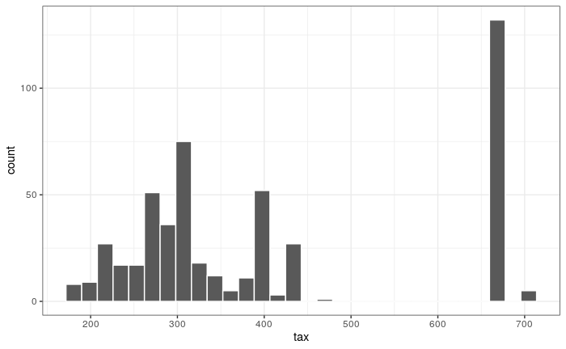

`ptratio` has a few low outliers:

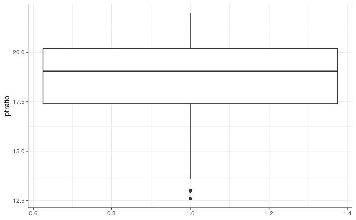

This isn’t obvious on the histogram, but the boxplot method deems them outliers:

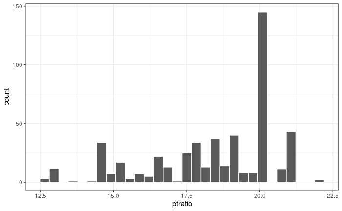

### (e)

35:

|  | chas | n |
| --- | --- | --- |
| 1 | 0 | 471 |
| 2 | 1 | 35 |

### (f)

```r
median(Boston$ptratio)
```

```
[1] 19.05
```

### (g)

Extract the minimum value of `medv` and compare the corresponding values of that row to the summary values of the whole data set:

```r
medv.min <- which.min(Boston$medv)
Boston[medv.min , ] %>% unlist()
```

```
    crim       zn    indus     chas      nox       rm      age      dis      rad      tax  ptratio    black    lstat     medv
 38.3518   0.0000  18.1000   0.0000   0.6930   5.4530 100.0000   1.4896  24.0000 666.0000  20.2000 396.9000  30.5900   5.0000
```

```r
summary(Boston)
```

```
      crim                zn             indus            chas              nox               rm             age              dis
 Min.   : 0.00632   Min.   :  0.00   Min.   : 0.46   Min.   :0.00000   Min.   :0.3850   Min.   :3.561   Min.   :  2.90   Min.   : 1.130
 1st Qu.: 0.08205   1st Qu.:  0.00   1st Qu.: 5.19   1st Qu.:0.00000   1st Qu.:0.4490   1st Qu.:5.886   1st Qu.: 45.02   1st Qu.: 2.100
 Median : 0.25651   Median :  0.00   Median : 9.69   Median :0.00000   Median :0.5380   Median :6.208   Median : 77.50   Median : 3.207
 Mean   : 3.61352   Mean   : 11.36   Mean   :11.14   Mean   :0.06917   Mean   :0.5547   Mean   :6.285   Mean   : 68.57   Mean   : 3.795
 3rd Qu.: 3.67708   3rd Qu.: 12.50   3rd Qu.:18.10   3rd Qu.:0.00000   3rd Qu.:0.6240   3rd Qu.:6.623   3rd Qu.: 94.08   3rd Qu.: 5.188
 Max.   :88.97620   Max.   :100.00   Max.   :27.74   Max.   :1.00000   Max.   :0.8710   Max.   :8.780   Max.   :100.00   Max.   :12.127
      rad              tax           ptratio          black            lstat            medv
 Min.   : 1.000   Min.   :187.0   Min.   :12.60   Min.   :  0.32   Min.   : 1.73   Min.   : 5.00
 1st Qu.: 4.000   1st Qu.:279.0   1st Qu.:17.40   1st Qu.:375.38   1st Qu.: 6.95   1st Qu.:17.02
 Median : 5.000   Median :330.0   Median :19.05   Median :391.44   Median :11.36   Median :21.20
 Mean   : 9.549   Mean   :408.2   Mean   :18.46   Mean   :356.67   Mean   :12.65   Mean   :22.53
 3rd Qu.:24.000   3rd Qu.:666.0   3rd Qu.:20.20   3rd Qu.:396.23   3rd Qu.:16.95   3rd Qu.:25.00
 Max.   :24.000   Max.   :711.0   Max.   :22.00   Max.   :396.90   Max.   :37.97   Max.   :50.00
```

View the ranks of the variables from the row containing the lowest value of `medv` (1 is lowest, 506 is highest)

```r
map_dbl(Boston, function(var) min_rank(var)[medv.min])
```

```
   crim      zn   indus    chas     nox      rm     age     dis     rad     tax ptratio   black   lstat    medv
    500       1     318       1     421      39     464      29     375     370     311     386     495       1
```

### (h)

How many of the suburbs average more than seven rooms per dwelling:

```r
Boston %>%
  filter(rm > 7) %>%
  nrow()
```

```
[1] 64
```

How many of the suburbs average more than eight rooms per dwelling:

```r
Boston %>%
  filter(rm > 8) %>%
  nrow()
```

```
[1] 13
```

```r
Boston %>%
  filter(rm > 8)
```

| crim | zn | indus | chas | nox | rm | age | dis | rad | tax | ptratio | black | lstat | medv |
| --- | --- | --- | --- | --- | --- | --- | --- | --- | --- | --- | --- | --- | --- |
| 0.12083 | 0 | 2.89 | 0 | 0.4450 | 8.069 | 76.0 | 3.4952 | 2 | 276 | 18.0 | 396.90 | 4.21 | 38.7 |
| 1.51902 | 0 | 19.58 | 1 | 0.6050 | 8.375 | 93.9 | 2.1620 | 5 | 403 | 14.7 | 388.45 | 3.32 | 50.0 |
| 0.02009 | 95 | 2.68 | 0 | 0.4161 | 8.034 | 31.9 | 5.1180 | 4 | 224 | 14.7 | 390.55 | 2.88 | 50.0 |
| 0.31533 | 0 | 6.20 | 0 | 0.5040 | 8.266 | 78.3 | 2.8944 | 8 | 307 | 17.4 | 385.05 | 4.14 | 44.8 |
| 0.52693 | 0 | 6.20 | 0 | 0.5040 | 8.725 | 83.0 | 2.8944 | 8 | 307 | 17.4 | 382.00 | 4.63 | 50.0 |
| 0.38214 | 0 | 6.20 | 0 | 0.5040 | 8.040 | 86.5 | 3.2157 | 8 | 307 | 17.4 | 387.38 | 3.13 | 37.6 |
| 0.57529 | 0 | 6.20 | 0 | 0.5070 | 8.337 | 73.3 | 3.8384 | 8 | 307 | 17.4 | 385.91 | 2.47 | 41.7 |
| 0.33147 | 0 | 6.20 | 0 | 0.5070 | 8.247 | 70.4 | 3.6519 | 8 | 307 | 17.4 | 378.95 | 3.95 | 48.3 |
| 0.36894 | 22 | 5.86 | 0 | 0.4310 | 8.259 | 8.4 | 8.9067 | 7 | 330 | 19.1 | 396.90 | 3.54 | 42.8 |
| 0.61154 | 20 | 3.97 | 0 | 0.6470 | 8.704 | 86.9 | 1.8010 | 5 | 264 | 13.0 | 389.70 | 5.12 | 50.0 |

[output cut: 3 more lines]

They tend to be expensive (high `medv`), crime is below average in every suburb, all suburbs are below average in terms of low-status residents.

[^1]: James G, Witten D, Hastie T, Tibshirani R (2013). *An Introduction to Statistical Learning: with Applications in R*. Springer, 1st edition.